# FigureYa266panHeatmap

**Author(s)**: Xiaofan Lu; Yasi Zhang  
**Reviewer(s)**: Ying Ge  
**Date**: 2025-05-20

# 需求描述

# Demand description

复现Figure1的EF，希望能用原始数据。

Replicate Figure 1E-F using raw data where possible.

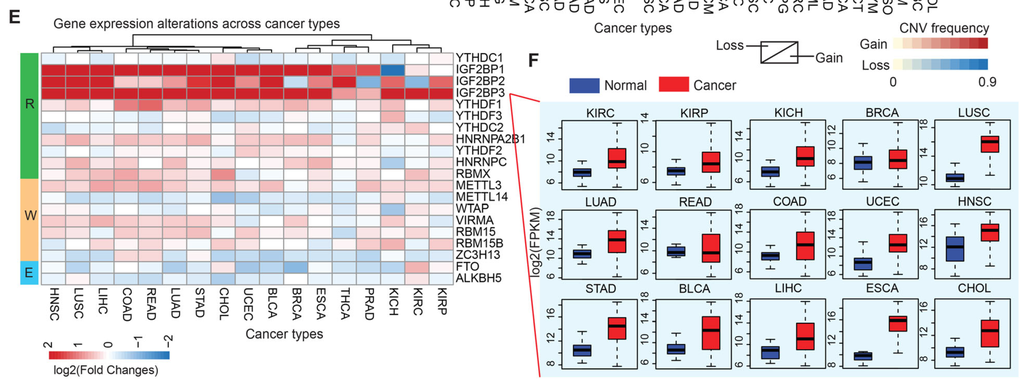

出自：https://molecular-cancer.biomedcentral.com/articles/10.1186/s12943-019-1066-3

图1 m6A调控因子的泛癌遗传学及表达改变 e 17种癌症类型中m6A调控因子的基因表达改变。热图显示倍数变化，红色代表上调基因，蓝色代表下调基因。 f 箱线图展示IGF2BP3在15种癌症类型的肿瘤和正常样本中的表达分布。

Source: https://molecular-cancer.biomedcentral.com/articles/10.1186/s12943-019-1066-3

Fig. 1 Pan-cancer genetic and expression alterations of m6A regulators. e The gene expression alterations of m6A regulators in 17 cancer types. The heat map shows the fold changes, with red representing up-regulated genes, and blue representing down-regulated genes. f Box plots showing the expression distribution of IGF2BP3 across tumor and normal samples in 15 cancer types.

# 应用场景

# Application scenarios

对泛癌中肿瘤与正常样本做多个基因（m6A为例）的差异表达分析，并根据log2FoldChange值绘制泛癌热图，同时对感兴趣基因绘制泛癌箱型图。

如果想换成泡泡图结合柱形图，可参考FigureYa263panDiff，https://k.youshop10.com/v5okDUEr

如果想用GSEA计算并展示多个**基因集**的差异表达，可参考FigureYa253panGSEA，https://k.youshop10.com/QbM6nwGB

如果只对单个基因感兴趣，可参考FigureYa55panCancer_violin，画成小提琴图或box plot，https://www.yuque.com/figureya/figureyaplus/figureya55p。

另外，我们还众筹过这篇文章的其他几个有意思的图：

- Fig.1D对角热图，可参考FigureYa144DiagHeatmap或https://mp.weixin.qq.com/s/34WRZRBVPHUNRLlzNH2nzw
- Fig.2A靶向关系连线图，可参考FigureYa199crosslink，https://k.youshop10.com/Zbb7VoNM，带你实现连线自由
- Fig.3A基因集的survival landscape，可参考FigureYa210survivalScape，https://k.youshop10.com/dDv=wvoj

更多泛癌FigureYa看这里，https://k.youshop10.com/C8RkTgR3

Perform differential expression analysis of multiple genes (using m6A as an example) between tumor and normal samples across pan-cancer datasets, and generate pan-cancer heatmaps based on log2FoldChange values, along with pan-cancer box plots for genes of interest.

To switch to bubble charts combined with bar plots, refer to FigureYa263panDiff https://k.youshop10.com/v5okDUEr

To use GSEA for calculating and displaying differential expression of **multiple gene sets**, refer to FigureYa253panGSEA https://k.youshop10.com/QbM6nwGB

If only interested in a single gene, refer to FigureYa55panCancer_violin to create violin plots or box plots https://www.yuque.com/figureya/figureyaplus/figureya55p.

For more pan-cancer FigureYa resources, see herehttps://k.youshop10.com/C8RkTgR3

# 环境设置

# Environment Setup

使用国内镜像安装包。

Using domestic mirrors for package installation.

```r
options("repos"= c(CRAN="https://mirrors.tuna.tsinghua.edu.cn/CRAN/"))
options(BioC_mirror="http://mirrors.tuna.tsinghua.edu.cn/bioconductor/")
```

# 加载包

# Loading packages

```r
library(data.table)
library(impute)
library(ClassDiscovery)
```

```r
library(ComplexHeatmap)
source("twoclasslimma.R")

# 显示英文报错信息
# Show English error messages
Sys.setenv(LANGUAGE = "en")

# 禁止chr转成factor
# Prevent character-to-factor conversion
options(stringsAsFactors = FALSE)
```

# 输入文件

# Input Files

跟FigureYa253panGSEA、FigureYa263panDiff、FigureYa265panCNV使用的是同一套输入数据，已经下载的小伙伴就不用重复下载了。

merged_sample_quality_annotations.tsv: 下载自https://gdc.cancer.gov/about-data/publications/pancanatlas，下载地址http://api.gdc.cancer.gov/data/1a7d7be8-675d-4e60-a105-19d4121bdebf

EBPlusPlusAdjustPANCAN_IlluminaHiSeq_RNASeqV2.geneExp.tsv: 表达矩阵，第一列是基因，之后是其在每个样本中的表达量。下载自http://api.gdc.cancer.gov/data/3586c0da-64d0-4b74-a449-5ff4d9136611

These files use the same input data as FigureYa253panGSEA, FigureYa263panDiff, and FigureYa265panCNV - if you’ve already downloaded them, no need to download again.

merged_sample_quality_annotations.tsv: Downloaded fromhttps://gdc.cancer.gov/about-data/publications/pancanatlas. Direct download link: http://api.gdc.cancer.gov/data/1a7d7be8-675d-4e60-a105-19d4121bdebf.

EBPlusPlusAdjustPANCAN_IlluminaHiSeq_RNASeqV2.geneExp.tsv: Expression matrix where the first column contains gene names, followed by expression values for each sample. Downloaded fromhttp://api.gdc.cancer.gov/data/3586c0da-64d0-4b74-a449-5ff4d9136611

```r
# 定义感兴趣的M6A基因集(VIRMA和KIAA1429同名，https://www.genecards.org/cgi-bin/carddisp.pl?gene=VIRMA)
# Define the M6A gene set of interest (VIRMA and KIAA1429 are the same gene, see: https://www.genecards.org/cgi-bin/carddisp.pl?gene=VIRMA)
m6a <- c("YTHDC1","IGF2BP1","IGF2BP2","IGF2BP3",
         "YTHDF1","YTHDF3","YTHDC2","HNRNPA2B1",
         "YTHDF2","HNRNPC","RBMX","METTL3",
         "METTL14","WTAP","KIAA1429","RBM15",
         "RBM15B","ZC3H13","FTO","ALKBH5")

# 获得同时有肿瘤和正常样本的肿瘤名
# Get tumor names that have both tumor and normal samples
tumors <- c("BLCA","BRCA","CESC","CHOL","COAD",
            "ESCA","GBM","HNSC","KICH","KIRC",
            "KIRP","LIHC","LUAD","LUSC","PAAD",
            "PRAD","READ","STAD","THCA","UCEC")

# 修正TCGA名称：https://gdc.cancer.gov/about-data/publications/pancanatlas
# Correct TCGA names: https://gdc.cancer.gov/about-data/publications/pancanatlas
rawAnno <- read.delim("merged_sample_quality_annotations.tsv",sep = "\t",row.names = NULL,check.names = F,stringsAsFactors = F,header = T)
# 简化样本ID（取前15位TCGA条码）
# Simplify sample IDs (first 15 characters of TCGA barcode)
rawAnno$simple_barcode <- substr(rawAnno$aliquot_barcode,1,15)

# 创建精简注释表（去重+关键列）
# Create concise annotation table (deduplicated + key columns)
samAnno <- rawAnno[!duplicated(rawAnno$simple_barcode),c("cancer type", "simple_barcode")]

# 过滤无效记录（癌症类型为空）
# Filter invalid records (empty cancer type)
samAnno <- samAnno[which(samAnno$`cancer type` != ""),]

# 保存简化版注释文件（供后续分析使用）
# Save simplified annotation (for downstream analysis)
write.table(samAnno,"simple_sample_annotation.txt",sep = "\t",row.names = F,col.names = T,quote = F)

# 快速读取表达谱: https://gdc.cancer.gov/about-data/publications/pancanatlas
# Quickly read expression profiles: https://gdc.cancer.gov/about-data/publications/pancanatlas
expr <- fread("EBPlusPlusAdjustPANCAN_IlluminaHiSeq_RNASeqV2.geneExp.tsv",sep = "\t",stringsAsFactors = F,check.names = F,header = T)

# 转换为数据框并设置行名
# Convert to dataframe and set row names
expr <- as.data.frame(expr); rownames(expr) <- expr[,1]; expr <- expr[,-1]

# 调整行名
# Adjust row names
gene <- sapply(strsplit(rownames(expr),"|",fixed = T), "[",1)

expr$gene <- gene

# 移除重复样本
# Remove duplicate samples
expr <- expr[!duplicated(expr$gene),]
rownames(expr) <- expr$gene; expr <- expr[,-ncol(expr)]

# 取部分表达谱，全部匹配
# Extract partial expression profiles, all matched
comgene <- intersect(rownames(expr),m6a)

# 提取m6A基因表达子集
# Extract m6A gene expression subset
expr_sub <- expr[comgene,]

# 简化样本ID（取前15位）
# Simplify sample IDs (first 15 characters)
colnames(expr_sub) <- substr(colnames(expr_sub),1,15)

# 去除重复样本（基于简化后的ID）
# Remove duplicate samples (based on simplified IDs)
expr_sub <- expr_sub[,!duplicated(colnames(expr_sub))]

# 内存清理
# Memory Cleanup
rm(expr); gc()
```

```
##           used  (Mb) gc trigger   (Mb)  max used   (Mb)
## Ncells 2560215 136.8    5147242  274.9   4152920  221.8
## Vcells 5948339  45.4  572684736 4369.3 715851570 5461.6
```

# 差异表达分析

# Differential Expression Analysis

```r
# 初始化差异表达矩阵以存储每个基因在每个癌种种类里的log2FoldChange值
# Initialize a differential expression matrix to store log2FoldChange values for each gene in each cancer type
degRes <- as.data.frame(matrix(NA,nrow = length(comgene),ncol = length(tumors),
                 dimnames = list(comgene,tumors)))

# 跨癌种差异表达分析
# Pan-Cancer Differential Expression Analys
for (i in tumors) {
  message("--",i,"...")

  # 获取当前癌症类型的样本ID
  # Get sample IDs for current cancer type
  sam <- samAnno[which(samAnno$`cancer type` == i),"simple_barcode"]

  # 获取表达矩阵和样本注释的交集
  # Get intersection between expression matrix and sample annotation
  comsam <- intersect(colnames(expr_sub), sam)

  # 获得肿瘤样本
  # Extract tumor samples
  tumsam <- comsam[substr(comsam,14,14) == "0"]

  # 获得正常样本
  # Extract normal samples
  norsam <- comsam[substr(comsam,14,14) == "1"]

  # 提取目标基因的表达子集
  # Extract expression subset for target genes
  expr_subset <- expr_sub[,c(tumsam,norsam)]

  # 这份数据里存在负值，即便负值比较小，但也要矫正，如果使用其他泛癌表达谱根据情况而定
  # This dataset contains negative values (though small), so correction is needed. Adjust if using other pan-cancer expression data
  expr_subset[expr_subset < 0] <- 0

  # 这份泛癌数据存在空值，所以做缺失值填补
  # Missing value imputation (this pan-cancer dataset contains NAs)
  expr_subset <- as.data.frame(impute.knn(as.matrix(expr_subset))$data)

  # 输出子表达谱
  # Output the subset expression profile
  write.table(expr_subset, paste0("TCGA_",i,"_expr_subset.txt"),sep = "\t",row.names = T,col.names = NA,quote = F)

  # 利用limma脚本做差异表达分析（脚本会识别数据的量级来确定是否进行对数化）
  # Perform differential expression analysis using the limma script (automatically checks data scale to determine if log transformation is needed)
  subt <- data.frame(condition = rep(c("tumor","normal"),c(length(tumsam),length(norsam))),
                     row.names = colnames(expr_subset),
                     stringsAsFactors = F)

  # 执行limma差异表达分析
  # Perform limma differential expression analysis
  twoclasslimma(subtype  = subt,
                featmat  = expr_subset,
                treatVar = "tumor",
                ctrlVar  = "normal",
                prefix   = paste0("TCGA_",i),
                overwt   = T,
                sort.p   = F,
                verbose  = TRUE,
                res.path = ".")

  # 加载差异表达文件
  # Load the differential expression results
  res <- read.table(paste0("TCGA_",i,"_limma_test_result.tumor_vs_normal.txt"),sep = "\t",row.names = 1,check.names = F,stringsAsFactors = F,header = T)

  # 将log2FC值存入结果矩阵
  # Store log2FC values in result matrix
  degRes[,i] <- res[rownames(degRes),"log2fc"]
}
```

```
## --BLCA...
```

```
## --log2 transformation done for feature matrix.
```

```
## limma of tumor_vs_normal done...
```

```
## --BRCA...
## --log2 transformation done for feature matrix.
```

```
## limma of tumor_vs_normal done...
```

```
## --CESC...
## --log2 transformation done for feature matrix.
```

```
## limma of tumor_vs_normal done...
```

```
## --CHOL...
## --log2 transformation done for feature matrix.
```

```
## limma of tumor_vs_normal done...
```

```
## --COAD...
## --log2 transformation done for feature matrix.
```

```
## limma of tumor_vs_normal done...
```

```
## --ESCA...
## --log2 transformation done for feature matrix.
```

```
## limma of tumor_vs_normal done...
```

```
## --GBM...
## --log2 transformation done for feature matrix.
```

```
## limma of tumor_vs_normal done...
```

```
## --HNSC...
## --log2 transformation done for feature matrix.
```

```
## limma of tumor_vs_normal done...
```

```
## --KICH...
## --log2 transformation done for feature matrix.
```

```
## limma of tumor_vs_normal done...
```

```
## --KIRC...
## --log2 transformation done for feature matrix.
```

```
## limma of tumor_vs_normal done...
```

```
## --KIRP...
## --log2 transformation done for feature matrix.
```

```
## limma of tumor_vs_normal done...
```

```
## --LIHC...
## --log2 transformation done for feature matrix.
```

```
## limma of tumor_vs_normal done...
```

```
## --LUAD...
## --log2 transformation done for feature matrix.
```

```
## limma of tumor_vs_normal done...
```

```
## --LUSC...
## --log2 transformation done for feature matrix.
```

```
## limma of tumor_vs_normal done...
```

```
## --PAAD...
## --log2 transformation done for feature matrix.
```

```
## limma of tumor_vs_normal done...
```

```
## --PRAD...
## --log2 transformation done for feature matrix.
```

```
## limma of tumor_vs_normal done...
```

```
## --READ...
## --log2 transformation done for feature matrix.
```

```
## limma of tumor_vs_normal done...
```

```
## --STAD...
## --log2 transformation done for feature matrix.
```

```
## limma of tumor_vs_normal done...
```

```
## --THCA...
## --log2 transformation done for feature matrix.
```

```
## limma of tumor_vs_normal done...
```

```
## --UCEC...
## --log2 transformation done for feature matrix.
```

```
## limma of tumor_vs_normal done...
```

```r
# 保存差异表达结果矩阵
# Save differential expression matrix
write.table(degRes,file = "log2fc of m6a genes between tumor and normal samples in pancancer.txt",sep = "\t",row.names = T,col.names = NA,quote = F)
```

上面“差异表达分析”输出的TCGA_*_limma_test_result.tumor_vs_normal.txt文件可无缝对接FigureYa59volcanohttps://k.youshop10.com/QFx3=Jj1，绘制美丽火山图。

The output file TCGA_*_limma_test_result.tumor_vs_normal.txt from the “Differential Expression Analysis” section can be directly used with FigureYa59volcanohttps://k.youshop10.com/QFx3=Jj1 to create high-quality volcano plots.

# 开始画图

# Plotting

## 绘制log2FoldChange的热图

## Generate a Heatmap of log2FoldChange Values

```r
# 使用差异表达结果数据
# Using differential expression results
indata <- degRes

# 对log2FC做聚类
# Cluster log2FC values
hcs <- hclust(distanceMatrix(as.matrix(indata), "euclidean"), "ward.D")

## 创建行注释
## Create row annotations
annRow <- data.frame(row.names = m6a,
                     class = rep(c("Readers","Writers","Erasers"),c(11,7,2)))

# 设置因子水平（控制显示顺序）
# Set factor levels (controls display order)
annRow$class <- factor(annRow$class, levels = c("Readers","Writers","Erasers"))

# 定义注释颜色方案
# Define annotation color scheme
annColors <- list(class = c("Readers" = "#51B743",
                            "Writers" = "#FAC67A",
                            "Erasers" = "#5AC9FA"))

# 设置热图的颜色板
# Set heatmap color gradient
colPattern <- c("#183869","#4195C1","white","#CB5746","#62011D")

# 热图绘制
# Heatmap Visualization
hm <- pheatmap(as.matrix(indata[rownames(annRow),]),
         border_color = "black",
         cluster_rows = FALSE,
         cluster_cols = hcs,
         show_rownames = TRUE,
         show_colnames = TRUE,
         annotation_row = annRow,
         annotation_colors = annColors,
         cellwidth = 18,
         cellheight = 12,
         color = colorRampPalette(colPattern)(64),
         name = "log2FoldChange")

# 保存热图为PDF
# Save heatmap as PDF
pdf(file = "pancancer heatmap of log2fc for m6A between tumor and normal samples.pdf", width = 8, height = 6)

# 绘制热图
# Draw heatmap
draw(hm)

# 静默关闭图形设备
# Silently close graphics device
invisible(dev.off())
```

[figure not shown]

## 批量绘制箱型图(y轴的标签可以最后用AI补上)

## Batch Generation of Box Plots (Y-axis labels can be added later using AI)

以`IGF2BP3`基因为例

Using the IGF2BP3 gene as an example

```r
# 设置感兴趣的基因
# Set gene of interest
geneInterest <- "IGF2BP3"

# 定义颜色方案
# Define color scheme
darkred <- "#F2042C"
darkblue <- "#21498D"

# 创建多页PDF输出文件
# Create multi-page PDF output
pdf(file = paste0("pancancer boxplot of ", geneInterest, " expression between tumor and normal samples.pdf"), width = 10,height = 10)

# 设置4行5列的图形布局（适应20种癌症类型）
# Set 4x5 graphical layout (for 20 cancer types)
par(mfrow = c(4,5))

# 跨癌种循环分析
# Pan-Cancer Iterative Analysis
for (i in tumors) {
  message("--",i,"...")

  # 获取当前癌症类型的样本ID
  # Get sample IDs for current cancer type
  sam <- samAnno[which(samAnno$`cancer type` == i),"simple_barcode"]

  # 获取表达矩阵和样本注释的交集
  # Get intersection between expression matrix and sample annotation
  comsam <- intersect(colnames(expr_sub), sam)

  # 获得肿瘤样本
  # Extract tumor samples
  tumsam <- comsam[substr(comsam,14,14) == "0"]

  # 获得正常样本
  # Extract normal samples
  norsam <- comsam[substr(comsam,14,14) == "1"]

  # 读入子表达谱
  # Load subset expression profile
  expr_subset <- read.table(paste0("TCGA_",i,"_expr_subset.txt"),sep = "\t",row.names = 1,check.names = F,stringsAsFactors = F,header = T)

  # 取出肿瘤样本特定基因的表达并对数化
  # Extract and log-transform tumor sample expression
  exprTgene <- log2(as.numeric(expr_subset[geneInterest,tumsam]) + 1)

  # 取出正常样本特定基因的表达并对数化
  # Extract and log-transform normal sample expression
  exprNgene <- log2(as.numeric(expr_subset[geneInterest,norsam]) + 1)

  # 为了使得图形尽可能紧凑，因为四边的距离分别设置为0.1（底部空出一小段距离），1.5（左边因为要放y轴刻度），2（顶部因为肿瘤名写在顶部），0.1（右部空出一小段距离）
  # Set plot parameters for compact display: 0.1 (bottom margin), 1.5 (left margin for y-axis), 2 (top margin for cancer type label), 0.1 (right margin)
  par(bty="o", mgp = c(1.5,.33,0),
      mar=c(0.1,1.5,2,0.1),
      las=1, tcl=-.25,las = 1, xpd = F)

  # 绘制肿瘤vs正常表达比较箱线图
  # Draw tumor vs normal expression boxplot
  boxplot(exprNgene,exprTgene,
          col = c(darkblue,darkred),
          outline = FALSE,
          ylab = "",
          xaxt='n')

  # 添加癌症类型标签（顶部）
  # Add cancer type label (top)
  mtext(side = 3, text = i,line = 0.5)
}
```

```
## --BLCA...
```

```
## --BRCA...
```

```
## --CESC...
```

```
## --CHOL...
```

```
## --COAD...
```

```
## --ESCA...
```

```
## --GBM...
```

```
## --HNSC...
```

```
## --KICH...
```

```
## --KIRC...
```

```
## --KIRP...
```

```
## --LIHC...
```

```
## --LUAD...
```

```
## --LUSC...
```

```
## --PAAD...
```

```
## --PRAD...
```

```
## --READ...
```

```
## --STAD...
```

```
## --THCA...
```

```
## --UCEC...
```

```r
# 静默关闭图形设备
# Silently close graphics device
invisible(dev.off())
```

[figure not shown]

# 会话信息